# week_1_house_prices

## Instructors

- Nguyễn Hoàng Phương - Data Scientist từ Torus-Actions

## Tổng quan về workshop

#### Phần thứ nhất: Bài toán regression - Xây dựng mô hình dự đoán giá nhà

Giới thiệu tổng quan về cách tiếp cận giải quyết bài toán regression thông qua dữ liệu của cuộc thi [House prices](https://www.kaggle.com/c/house-prices-advanced-regression-techniques). Phần này sẽ giới thiệu qua về các hạng mục chính như xây dựng mô hình cơ bản (khai phá dữ liệu, xử lý dữ liệu, xây dựng mô hình cơ bản, tối ưu bayes, thuật toán lightgbm, finetune tham số ,…)

#### Phần thứ hai: Bài toán Classification - Xây dựng mô hình chấm điểm tín dụng

Giới thiệu tổng quan về cách tiếp cận giải quyết bài toán classification, thông qua sử dụng các kỹ thuật phổ biến áp dụng trực tiếp cho dữ liệu của TPBank khi xây dựng mô hình đánh giá tín nhiệm KH. Giới thiệu các điểm quan trọng khi thu thập và xử lý dữ liệu để xây dựng mô hình dự đoán, các lưu ý quan trọng khác cho bài toán thực tế.

## Yêu cầu cài đặt

```
numpy==1.19.3
scipy==1.5.3
matplotlib==3.3.2
seaborn==0.11.0
scikit-learn==0.23.2
pandas==1.1.3
xgboost==0.81
lightgbm==3.0.0
bayesian-optimization==1.2.0
```

# Phần I - Tuần 1: Bài toán Regression - xây dựng mô hình dự đoán giá nhà

[figure not shown]

### Mô tả :

- Dữ liệu huấn luyện (trainig set): Là một bảng biểu bao gồm
  - đầu vào: thông tin tổng quan của một căn nhà (diện tích các phòng, các thang điểm đánh giá căn nhà,... )
  - đầu ra: Giá bán của căn nhà tại một thời điểm.
- Mục đích: Xây dựng mô hình học máy dựa trên tập training (bao gồm đầu vào và đầu ra) để dự đoán giá của căn nhà (không có trên tập training) khi biết trước các số liệu tổng quan.

## Tham khảo

#### Kaggle

- [House prices competition](https://www.kaggle.com/c/house-prices-advanced-regression-techniques)
- [Comprehensive data exploration](https://www.kaggle.com/pmarcelino/comprehensive-data-exploration-with-python)
- [Stacked regressions to predict House Prices](https://www.kaggle.com/serigne/stacked-regressions-top-4-on-leaderboard)

#### Coursera

- [Applied Data Science with Python](https://www.coursera.org/specializations/data-science-python)
- [Data Visualization with Python](https://www.coursera.org/learn/python-for-data-visualization)

## Outline

- 1. Giới thiệu dữ liệu
  - 1.1. Thông tin tổng quan dữ liệu
  - 1.2. Thông tin tổng quan target
  - 1.3. Metric đánh giá
- 2. Khai phá dữ liệu
  - 2.1. Tổng quan dữ liệu thiếu
  - 2.2. Trường dữ liệu số (numeric)
  - 2.3. Trường dữ liệu phân loại (categorical)
- 3. Feature engineering
  - 3.1. Xử lý dữ liệu thiếu
  - 3.2. Xử lý dữ liệu số
  - 3.3. Xử lý dữ liệu phân loại
- 4. Xây dựng mô hình
  - 3.1. Xây dựng validation
  - 3.2. Xây dựng mô hình

### Nhập các gói thư viện

```python
# import packages
# thu vien doc du lieu bang
import pandas as pd
# thu vien in hình anh
import matplotlib.pyplot as plt
import seaborn as sns
import numpy as np
# thu vien tinh toan
from scipy.stats import norm
from scipy import stats
import warnings
warnings.filterwarnings('ignore')
%matplotlib inline
# thu vien chia Kfold
from sklearn.model_selection import KFold
# thu vien chia tinh toan mean_square_error
from sklearn.metrics import mean_squared_error
import lightgbm as lgb
```

### Đọc file dữ liệu

```python
#read file
train = pd.read_csv('./data/house-prices/train.csv')
test  = pd.read_csv('./data/house-prices/test.csv')
```

# 1.Giới thiệu về data

```python
train.head(5)
```

|  | Id | MSSubClass | MSZoning | LotFrontage | LotArea | Street | Alley | LotShape | LandContour | Utilities | ... | PoolArea | PoolQC | Fence | MiscFeature | MiscVal | MoSold | YrSold | SaleType | SaleCondition | SalePrice |
| --- | --- | --- | --- | --- | --- | --- | --- | --- | --- | --- | --- | --- | --- | --- | --- | --- | --- | --- | --- | --- | --- |
| 0 | 1 | 60 | RL | 65.0 | 8450 | Pave | NaN | Reg | Lvl | AllPub | ... | 0 | NaN | NaN | NaN | 0 | 2 | 2008 | WD | Normal | 208500 |
| 1 | 2 | 20 | RL | 80.0 | 9600 | Pave | NaN | Reg | Lvl | AllPub | ... | 0 | NaN | NaN | NaN | 0 | 5 | 2007 | WD | Normal | 181500 |
| 2 | 3 | 60 | RL | 68.0 | 11250 | Pave | NaN | IR1 | Lvl | AllPub | ... | 0 | NaN | NaN | NaN | 0 | 9 | 2008 | WD | Normal | 223500 |
| 3 | 4 | 70 | RL | 60.0 | 9550 | Pave | NaN | IR1 | Lvl | AllPub | ... | 0 | NaN | NaN | NaN | 0 | 2 | 2006 | WD | Abnorml | 140000 |
| 4 | 5 | 60 | RL | 84.0 | 14260 | Pave | NaN | IR1 | Lvl | AllPub | ... | 0 | NaN | NaN | NaN | 0 | 12 | 2008 | WD | Normal | 250000 |

5 rows × 81 columns

```python
print('Kích thước tập train: {}'.format(train.shape))
print('Kích thước tập test : {}'.format(test.shape))
```

```
Kích thước tập train: (1460, 81)
Kích thước tập test : (1459, 80)
```

- Tập train có 80 trường dữ liệu (không bao gồm cột ID)
- Tập test có 79 trường dữ liệu (không bao gồm cột ID)

### Tìm hiểu các hàng có trùng nhau hay không?

```python
# Find a duplicate rows
duplicate_row = train[train.duplicated()]
print(duplicate_row)
```

```
Empty DataFrame
Columns: [Id, MSSubClass, MSZoning, LotFrontage, LotArea, Street, Alley, LotShape, LandContour, Utilities, LotConfig, LandSlope, Neighborhood, Condition1, Condition2, BldgType, HouseStyle, OverallQual, OverallCond, YearBuilt, YearRemodAdd, RoofStyle, RoofMatl, Exterior1st, Exterior2nd, MasVnrType, M…
Index: []

[0 rows x 81 columns]
```

Không có 2 hàng nào có dữ liệu trùng nhau hoàn toàn.

# 1.1. Thông tin các trường dữ liệu

```python
train.drop("Id", axis = 1, inplace = True)
test.drop("Id", axis = 1, inplace = True)
```

```python
train.columns
```

```
Index(['MSSubClass', 'MSZoning', 'LotFrontage', 'LotArea', 'Street', 'Alley',
       'LotShape', 'LandContour', 'Utilities', 'LotConfig', 'LandSlope',
       'Neighborhood', 'Condition1', 'Condition2', 'BldgType', 'HouseStyle',
       'OverallQual', 'OverallCond', 'YearBuilt', 'YearRemodAdd', 'RoofStyle',
       'RoofMatl', 'Exterior1st', 'Exterior2nd', 'MasVnrType', 'MasVnrArea',
       'ExterQual', 'ExterCond', 'Foundation', 'BsmtQual', 'BsmtCond',
       'BsmtExposure', 'BsmtFinType1', 'BsmtFinSF1', 'BsmtFinType2',
       'BsmtFinSF2', 'BsmtUnfSF', 'TotalBsmtSF', 'Heating', 'HeatingQC',
       'CentralAir', 'Electrical', '1stFlrSF', '2ndFlrSF', 'LowQualFinSF',
       'GrLivArea', 'BsmtFullBath', 'BsmtHalfBath', 'FullBath', 'HalfBath',
       'BedroomAbvGr', 'KitchenAbvGr', 'KitchenQual', 'TotRmsAbvGrd',
       'Functional', 'Fireplaces', 'FireplaceQu', 'GarageType', 'GarageYrBlt',
       'GarageFinish', 'GarageCars', 'GarageArea', 'GarageQual', 'GarageCond',
       'PavedDrive', 'WoodDeckSF', 'OpenPorchSF', 'EnclosedPorch', '3SsnPorch',
       'ScreenPorch', 'PoolArea', 'PoolQC', 'Fence', 'MiscFeature', 'MiscVal',
       'MoSold', 'YrSold', 'SaleType', 'SaleCondition', 'SalePrice'],
      dtype='object')
```

#### Các cột dữ liệu được mô tả ở file "data_description.txt".

Ngoài ra có thể tìm hiểu thông tin mô tả các trường dữ liệu ở [link](https://www.kaggle.com/c/house-prices-advanced-regression-techniques/data)

#### Một số thông tin tổng quan của bảng biểu giá nhà:

- SalePrice — Giá bán của bất động sản được tính bằng USD (ex: 181500 USD), đây là label của dữ liệu
- MSSubClass — Kiểu nhà và thông tin liên quan đến việc mua bán (ex: 1-STORY 1946 & NEWER ALL STYLES )
- MSZoning — Phân loại khu vực của nhà cần bán (ex: Agriculture, Residential High Density, ... )
- LotFrontage — Số "feet" (1 feet = 30.48 cm) từ nhà tới đường (ex: 50, 51, ...)
- LotArea — Số feet square của căn nhà (1 feet square = 0.0929 mét vuông), (ex: 6120,...)
- Street — Loại đường (Type pf road access)
- Alley — Loại lối vào hẻm (ex: Grvl- Gravel, Pave-Paved)
- LotShape — General shape of property
- LandContour — Độ phẳng của nhà (ex: Lvl : Near Flat/Level, Low : Depression )
- Utilities — Các loại tiện ích có sẵn (eg: All public Utilities, Electricity only )
- LotConfig — Thông tin vị trí nhà, ở góc, nhà 2 mặt đường,... (ex: Inside lot, Frontage on 2 sides of property)

Mục đích xây dựng mô hình dự đoán giá nhà cuối cùng (SalePrice) dựa vào thông tin của 79 trường dữ liệu (hoặc dữ liệu ngoài )

# 1.2. Thông tin tổng quan target

```python
train['SalePrice'].describe()
```

```
count      1460.000000
mean     180921.195890
std       79442.502883
min       34900.000000
25%      129975.000000
50%      163000.000000
75%      214000.000000
max      755000.000000
Name: SalePrice, dtype: float64
```

# 1.2.1 Phân bố của trường target

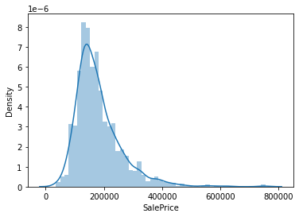

```python
sns.distplot(train['SalePrice'])
```

# 1.3 Chọn metric đánh giá

Chúng ta có thể thấy là target có giá trị khá lớn. Với những dữ liệu này, thường sẽ sử dụng Root Mean Squared Logarithmic Error (RMSLE) làm thước đo đánh giá mức độ chính xác của mô hình. RMSLE được tính bằng công thức

\begin{equation*} \epsilon = \sqrt{\frac{\sum_{t=1}^{n}(\log (y_t+1)-\log (\widehat{y_t}+1))^2}{n}}, \end{equation*}

trong đó,

- $\epsilon$ là giá trị RMSLE,
- $n$ là tổng số quan sát trong tập dữ liệu,
- $\widehat{y_t}$ là giá trị dự đoán của mô hình của mẫu thứ $t$
- $y_t$ là target của mẫu thứ $t$.

# 2 Khai phá dữ liệu (EDA)

# 2.1 Xem xét dữ liệu thiếu (missing data)

Hàm in ra tỉ lệ dữ thiếu (missing data) của các trường dữ liệu

```python
def missing_values_table(df):
    # Total missing values
    mis_val = df.isnull().sum()
    # Percentage of missing values
    mis_val_percent = 100 * df.isnull().sum() / len(df)
    # Make a table with the results
    mis_val_table = pd.concat([mis_val, mis_val_percent], axis=1)
    # Rename the columns
    mis_val_table_ren_columns = mis_val_table.rename(
    columns = {0 : 'Missing Values', 1 : '% of Total Values'})
    # Sort the table by percentage of missing descending
    mis_val_table_ren_columns = mis_val_table_ren_columns[
            mis_val_table_ren_columns.iloc[:,1] != 0].sort_values(
    '% of Total Values', ascending=False).round(1)
    return mis_val_table_ren_columns
```

```python
missing_values_table(train).head(10)
```

|  | Missing Values | % of Total Values |
| --- | --- | --- |
| PoolQC | 1453 | 99.5 |
| MiscFeature | 1406 | 96.3 |
| Alley | 1369 | 93.8 |
| Fence | 1179 | 80.8 |
| FireplaceQu | 690 | 47.3 |
| LotFrontage | 259 | 17.7 |
| GarageType | 81 | 5.5 |
| GarageYrBlt | 81 | 5.5 |
| GarageFinish | 81 | 5.5 |
| GarageQual | 81 | 5.5 |

### Dựa vào bảng dữ liệu thống kê các dữ liệu thiếu có thể ít nhiều thấy sự tương quan (correlation) giữa các cột dữ liệu, từ có có định hướng tốt hơn khi phân tích dữ liệu trong các bước tiếp theo:

- Các cột "GarageType", "GarageYrBlt", "GarageFinis", "GarageQual", "GarageCond" có mối quan hệ với nhau (cùng mô tả thông tin về garage nhà).
- Trong một số trường hợp, các cột có tỷ lệ missing giống nhau sẽ có correlation cao => có thể xóa đi các cột ít thông tin hơn.
- Dữ liệu thiếu thường do các nguyên nhân:
  - Điều kiện chủ quan (nhầm lẫn, điền thiếu thông tin khi thống kê, ...)
  - Điều kiện khách quan (bản thân missing data chứa đựng thông tin. Ví dụ: NaN từ các cột GarageType xuất phát từ nguyên nhân nhà không có garage)

### Phân loại các cột dữ liệu:

- Đối với dữ liệu bảng biểu, có 2 loại dữ liệu chính: dữ liệu dạng phân loại (categorical) và dữ liệu số (numeric). Ngoài ra còn có dữ liệu text, workshop sẽ không đi sâu vào loại dữ liệu này
- Việc phân loại và nhận biết dữ liệu giúp chúng ta có thể có cách xử lý tốt với từng loại dữ liệu

```python
train.dtypes.value_counts()
```

```
object     43
int64      34
float64     3
dtype: int64
```

# 2.1* Phân tích target (SalePrice)

### Tổng quan về target

```python
train.SalePrice.describe()
```

```
count      1460.000000
mean     180921.195890
std       79442.502883
min       34900.000000
25%      129975.000000
50%      163000.000000
75%      214000.000000
max      755000.000000
Name: SalePrice, dtype: float64
```

Hàm Series.describes() đưa ra các giá trị count, mean, std, min, max, ... của một chuỗi.

Từ hàm thống kê trên cũng cho thấy:

- Hầu hết giá trị nhà nằm trong khoảng $[130.000, 215.000]$
- Có sự sai lệch lớn giữa giá trị $min$ và $max$ ($35.000$ vs $755.000$)

Với các bài toán regression, khi có sự sai lệch (skewed) lớn ở trường numeric, chúng ta có thể sử dụng các phép biến đổi $np.log1p()$

```
Skew is: 1.8828757597682129
```

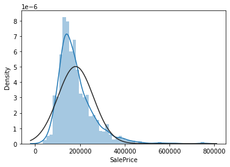

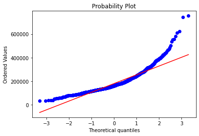

```python
sns.distplot(train['SalePrice'], fit=norm);
fig = plt.figure()
res = stats.probplot(train['SalePrice'], plot=plt)
print ("Skew is:", train.SalePrice.skew())
```

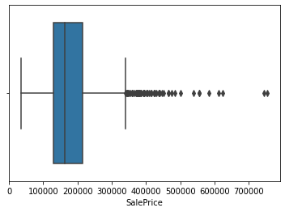

```python
sns.boxplot(train['SalePrice'], orient='v' )
```

Từ 3 đồ thị trên chúng ta có một số nhận xét:

- Biến giá nhà (SalePrice) không phải là phân phối chuẩn
- Biến giá nhà bị lệch về bên phải (right-skewed)
- Có nhiều khoảng giá trị bất thường (outlier)

### Sử dụng transform log(1+x) cho trường target

Chúng ta sử dụng phép biến đổi log cho target vì:

- Metric được tính toán dựa trên RMSLE
- Sử dụng biến đổi log giúp cho cột dữ liệu ít bị sai lệch (skewed) hơn
- Giá trị target có thể hồi phục lại bằng cách sử dụng phép biến đổi ngược (phép biến đổi exp)

```
Skew is: 0.12134661989685333
```

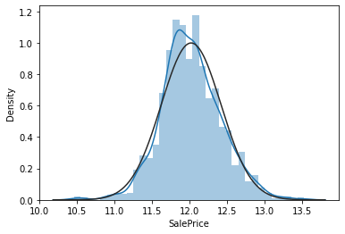

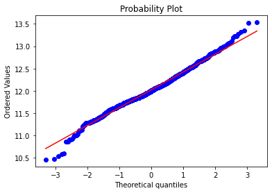

```python
sns.distplot(np.log1p(train['SalePrice']), fit=norm);
fig = plt.figure()
res = stats.probplot(np.log1p(train['SalePrice']), plot=plt)
print ("Skew is:", np.log1p(train.SalePrice).skew())
```

# 2.1. Phân tích dữ liệu số

Sử dụng hàm .select_dtypes() để trả về các cột có dữ liệu số (hoặc phân loại)

```python
numeric_features = train.select_dtypes(include=[np.number])
```

# 2.1.1 Ma trận correlation

Bảng correlation cho thấy sự tương quan giữa các trường dữ liệu có dạng số, từ đó giúp định hướng phân tích các cột dữ liệu.

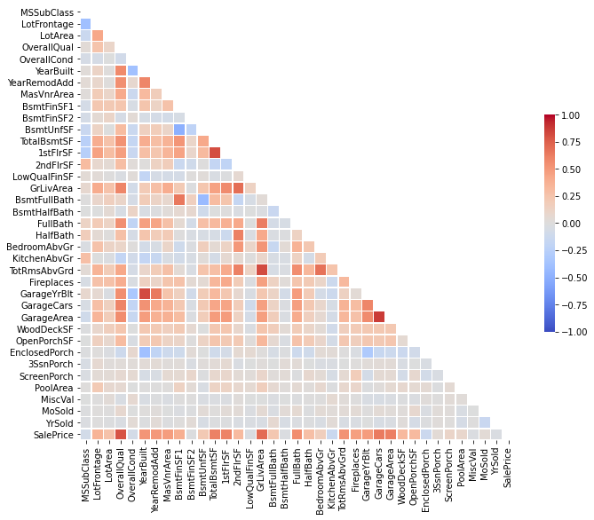

```python
corr = train.corr()  # Compute the correlation matrix
mask = np.zeros_like(corr, dtype=np.bool)
mask[np.triu_indices_from(mask)]= True # Generate a mask for the upper triangle
f, ax = plt.subplots(figsize=(12, 9))# Set up the matplotlib figure
sns.heatmap(corr, mask=mask, cmap='coolwarm',
            vmin = -1,vmax = 1, center=0,
            square=True, linewidths=.5, cbar_kws={"shrink": .5})# Draw the heatmap with the mask and correct aspect ratio
```

- Ma trận heatmap là cách tốt nhất để thấy được mối quan hệ giữa các trường số với nhau.
- Mỗi tọa độ của ma trận thể hiện mối tương quan giữa 2 cột.
- Correlation càng gần 1, thì 2 trường càng có sự giống nhau.
- Nếu các trường (khác target) có correlation cao, có thể xem xét bỏ đi một cột.
- Nếu một trường có correlation cao với target, thì trường đó được xem xét như một feature quan trọng.

# 2.1.2 Correlation giữa các trường với target (SalePrice)

Vẽ heatmap của ma trận correlation giữa target và 15 trường có có correlation cao nhất

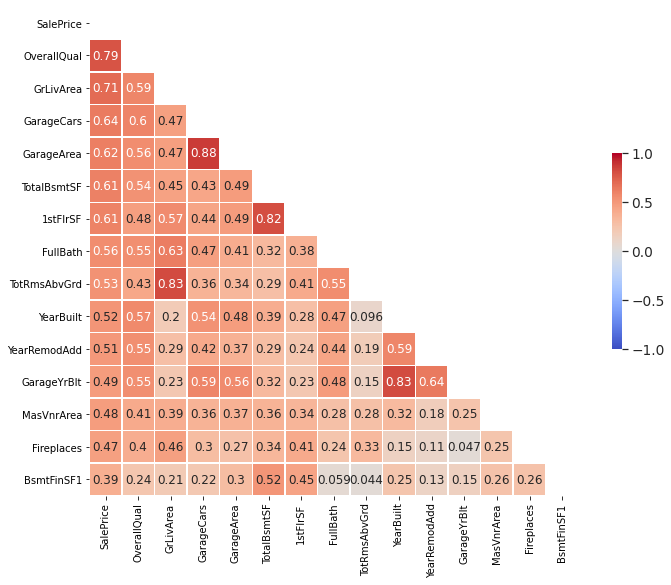

```python
f, ax = plt.subplots(figsize=(12, 9))
k = 15 #number of variables for heatmap
cols = corr.nlargest(k, 'SalePrice')['SalePrice'].index
#cm = np.corrcoef(train[cols].values.T)
cm = train[cols].corr()
mask = np.zeros_like(cm, dtype=np.bool)
mask[np.triu_indices_from(mask)]= True
sns.set(font_scale=1.25)
hm = sns.heatmap(cm, mask = mask, square = True,
                 linewidths = .5,
                 cmap = 'coolwarm',
                 cbar_kws = {'shrink': .4,
                             'ticks' : [-1, -.5, 0, 0.5, 1]},
                 vmin = -1,
                 vmax = 1,
                 annot = True,
                 annot_kws = {'size': 12},
                 yticklabels=cols.values, xticklabels=cols.values)
plt.show()
```

- In ra 15 trường có correlation cao nhất với target
- Trong đó có 11 trường có correlation lớn hơn 0.5

# 2.1.3 Quan sát

- 'OverallQual', 'GrLivArea' có mối quan hệ chặt chẽ với 'SalePrice'.
  - OverallQual: Trường chứa thông tin đánh giá vật liệu tổng thể và hoàn thiện của ngôi nhà, xếp từ 1 đến 10. 1: Very poor, 10: very excellent
  - GrLivArea: Diện tích sống của căn nhà
- 'GarageCars', 'GarageArea' cũng là feature quan trọng và chúng có mối quan hệ chặt chẽ với nhau
  - GarageCars: Diện tích chứa được của garage
  - GarageArea: Diện tích thật của garage
- 'TotalBsmtSF' và '1stFloor' cũng có mối quan hệ chặt chẽ với nhau
  - 'TotalBsmtSF': Tổng diện tích tầng hầm
  - '1stFloor': Tổng diện tích tầng 1

### Kiểm tra mối tương quan (correlation) giữa target và các trường dữ liệu số

- SalePrice và GrLivArea:

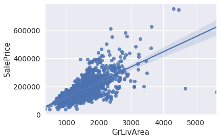

```python
#scatter plot grlivarea/saleprice
var = 'GrLivArea'
#scatter plot
sns.regplot(data = train, x= var, y="SalePrice")
```

Nhận xét :

- Thấy mối quan hệ "tuyến tính" giữa trường 'GrLivArea' và target
- Có một số giá trị ngoại lệ (outlier). Những hàng có giá trị "Grlivrea" (Diện tích nhà) đạt giá trị trên 4500, nhưng giá nhà dưới 200.000
- Kiểm tra những hàng dữ liệu bất thường (outlier)

```python
train.loc[(train['GrLivArea']>4500)&(train['SalePrice']<200000)]
```

|  | MSSubClass | MSZoning | LotFrontage | LotArea | Street | Alley | LotShape | LandContour | Utilities | LotConfig | ... | PoolArea | PoolQC | Fence | MiscFeature | MiscVal | MoSold | YrSold | SaleType | SaleCondition | SalePrice |
| --- | --- | --- | --- | --- | --- | --- | --- | --- | --- | --- | --- | --- | --- | --- | --- | --- | --- | --- | --- | --- | --- |
| 523 | 60 | RL | 130.0 | 40094 | Pave | NaN | IR1 | Bnk | AllPub | Inside | ... | 0 | NaN | NaN | NaN | 0 | 10 | 2007 | New | Partial | 184750 |
| 1298 | 60 | RL | 313.0 | 63887 | Pave | NaN | IR3 | Bnk | AllPub | Corner | ... | 480 | Gd | NaN | NaN | 0 | 1 | 2008 | New | Partial | 160000 |

2 rows × 80 columns

#### Lưu trữ lại các quan sát có số liệu bất thường

```python
outlier_raws = [523, 1298]
```

#### SalePrice và OverallQual:

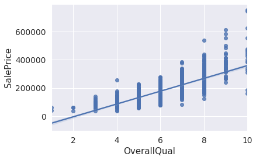

```python
#scatter plot grlivarea/saleprice
var = 'OverallQual'
#scatter plot
sns.regplot(data = train, x= var, y="SalePrice")
```

Thấy mối quan hệ "tuyến tính" giữa trường 'OverallQual' và target

### Xem xét distribution của các trường quan trọng

#### Trường GrLivArea (Tổng diện tích căn nhà)

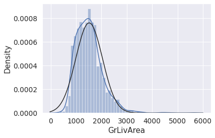

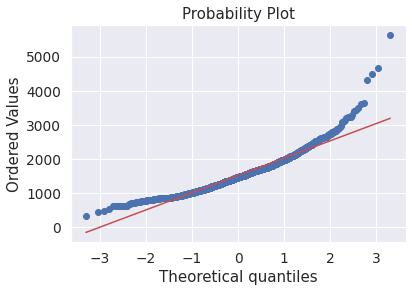

```python
#histogram and normal probability plot
sns.distplot(train['GrLivArea'], fit=norm);
fig = plt.figure()
res = stats.probplot(train['GrLivArea'], plot=plt)
```

### Trường GrLivArea sau khi sử dụng transform log

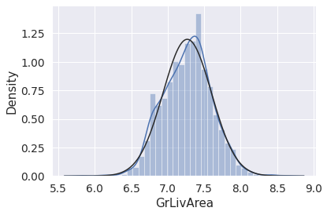

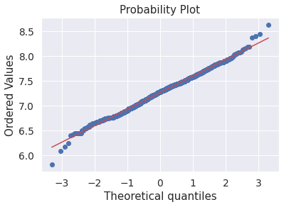

```python
sns.distplot(np.log1p(train['GrLivArea']), fit=norm);
fig = plt.figure()
res = stats.probplot(np.log1p(train['GrLivArea']), plot=plt)
```

Có thể thấy phân phối của trường log của "GrLivArea" gần với phân phối chuẩn

#### Trường TotalBsmtSF

Sử dụng phương pháp tương tự với trường dữ liệu TotalBsmtSF (Tổng diện tích tầng hầm)

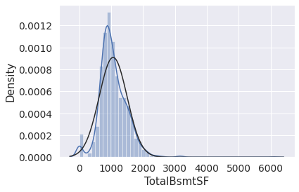

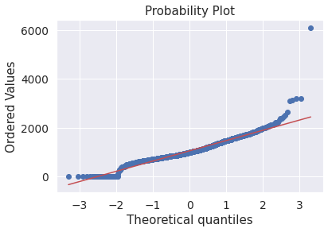

```python
sns.distplot(train['TotalBsmtSF'], fit=norm);
fig = plt.figure()
res = stats.probplot(train['TotalBsmtSF'], plot=plt)
```

Sử dụng phép biến đổi log(1+x) cho trường dữ liệu "TotalBsmtSF"

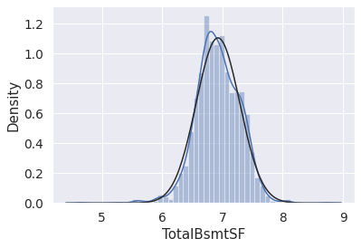

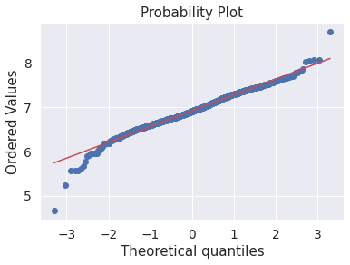

```python
sns.distplot(np.log(train[np.log1p(train['TotalBsmtSF'])>0]['TotalBsmtSF']), fit=norm);
fig = plt.figure()
res = stats.probplot(np.log(train[np.log1p(train['TotalBsmtSF'])>0]['TotalBsmtSF']), plot=plt)
```

# 2.2. Phân tích dữ liệu phân loại (Categorical)

# 2.2.1. Tổng quan dữ liệu phân loại (Categorical)

```python
categoricals = train.select_dtypes(exclude=[np.number])
categoricals.describe()
```

|  | MSZoning | Street | Alley | LotShape | LandContour | Utilities | LotConfig | LandSlope | Neighborhood | Condition1 | ... | GarageType | GarageFinish | GarageQual | GarageCond | PavedDrive | PoolQC | Fence | MiscFeature | SaleType | SaleCondition |
| --- | --- | --- | --- | --- | --- | --- | --- | --- | --- | --- | --- | --- | --- | --- | --- | --- | --- | --- | --- | --- | --- |
| count | 1460 | 1460 | 91 | 1460 | 1460 | 1460 | 1460 | 1460 | 1460 | 1460 | ... | 1379 | 1379 | 1379 | 1379 | 1460 | 7 | 281 | 54 | 1460 | 1460 |
| unique | 5 | 2 | 2 | 4 | 4 | 2 | 5 | 3 | 25 | 9 | ... | 6 | 3 | 5 | 5 | 3 | 3 | 4 | 4 | 9 | 6 |
| top | RL | Pave | Grvl | Reg | Lvl | AllPub | Inside | Gtl | NAmes | Norm | ... | Attchd | Unf | TA | TA | Y | Gd | MnPrv | Shed | WD | Normal |
| freq | 1151 | 1454 | 50 | 925 | 1311 | 1459 | 1052 | 1382 | 225 | 1260 | ... | 870 | 605 | 1311 | 1326 | 1340 | 3 | 157 | 49 | 1267 | 1198 |

4 rows × 43 columns

- unique: Số lớp phân loại của trường
- count: Số quan sát (không bao gồm dữ liệu thiếu)
- top: Lớp phân loại có tuần suất xuất hiện lớn nhất
- freq: Số lần xuất hiện của lớp phân loại có tần suất lớn nhất

Ví dụ, nhìn vào bảng, quan sát trường dữ liệu "GarageType": có 1379 dữ liệu không NAN, có 6 lớp phân loại, phân loại "attchd" có tuần suất xuất hiện nhiều nhất với 870/1460 lần.

# 2.2.2. Quan sát một số trường phân loại (Categorical)

Sử dụng lệnh select_dtypes(exclude=[np.number]) để tìm kiếm các trường phân loại

```python
categorical_features = train.select_dtypes(exclude=[np.number])
categorical_features.columns
```

```
Index(['MSZoning', 'Street', 'Alley', 'LotShape', 'LandContour', 'Utilities',
       'LotConfig', 'LandSlope', 'Neighborhood', 'Condition1', 'Condition2',
       'BldgType', 'HouseStyle', 'RoofStyle', 'RoofMatl', 'Exterior1st',
       'Exterior2nd', 'MasVnrType', 'ExterQual', 'ExterCond', 'Foundation',
       'BsmtQual', 'BsmtCond', 'BsmtExposure', 'BsmtFinType1', 'BsmtFinType2',
       'Heating', 'HeatingQC', 'CentralAir', 'Electrical', 'KitchenQual',
       'Functional', 'FireplaceQu', 'GarageType', 'GarageFinish', 'GarageQual',
       'GarageCond', 'PavedDrive', 'PoolQC', 'Fence', 'MiscFeature',
       'SaleType', 'SaleCondition'],
      dtype='object')
```

#### Lưu trữ lại các trường phân loại

```python
categorical_columns = ['MSZoning', 'Street', 'Alley', 'LotShape', 'LandContour', 'Utilities',
       'LotConfig', 'LandSlope', 'Neighborhood', 'Condition1', 'Condition2',
       'BldgType', 'HouseStyle', 'RoofStyle', 'RoofMatl', 'Exterior1st',
       'Exterior2nd', 'MasVnrType', 'ExterQual', 'ExterCond', 'Foundation',
       'BsmtQual', 'BsmtCond', 'BsmtExposure', 'BsmtFinType1', 'BsmtFinType2',
       'Heating', 'HeatingQC', 'CentralAir', 'Electrical', 'KitchenQual',
       'Functional', 'FireplaceQu', 'GarageType', 'GarageFinish', 'GarageQual',
       'GarageCond', 'PavedDrive', 'PoolQC', 'Fence', 'MiscFeature',
       'SaleType', 'SaleCondition']
```

#### Đối với bài toán regression, với các trường phân loại (categorical), chúng ta có thể phân tích theo 2 hướng chính:

- Tính tần suất xuất hiện, để xem xét sự phân bố của các lớp phân loại
- Tính trung bình của target đối với mỗi lớp phân loại

#### Trường Sale Condition

- Tần suất xuất hiện của trường Sale Condition

```python
def plot_feature(X):
    y = train.loc[X.index, 'SalePrice']
    plt.scatter(X, y)
    plt.xlabel('phân loại')
    plt.ylabel('SalePrice')
    plt.title(X.name)
```

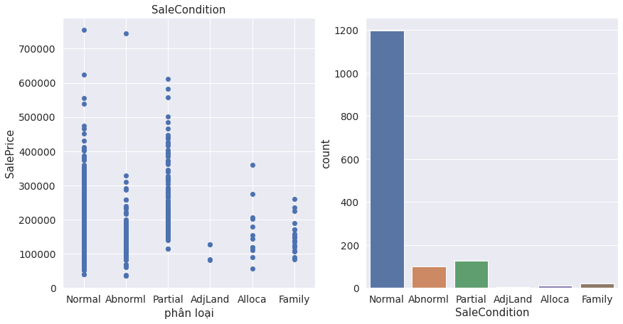

```python
feature = 'SaleCondition'
X = train[feature].dropna()
fig , (ax1, ax2) = plt.subplots(1,2, figsize=(14,7), sharex=True)
plt.subplot(ax1)
plot_feature(X)
plt.subplot(ax2)
if train[feature].dtype == np.dtype('object'):
    sns.countplot(X)
else:
    sns.distplot(X)
```

#### Xem giá nhà trung bình của các phân loại của trường Sale Condition

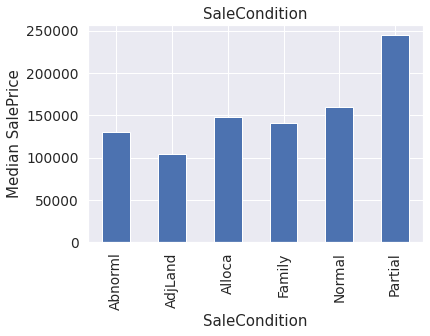

```python
train.groupby('SaleCondition')['SalePrice'].median().plot.bar()
plt.xlabel('SaleCondition')
plt.ylabel('Median SalePrice')
plt.title('SaleCondition')
plt.show()
```

#### Trường dữ liệu Utilities

```
<function matplotlib.pyplot.show(close=None, block=None)>
```

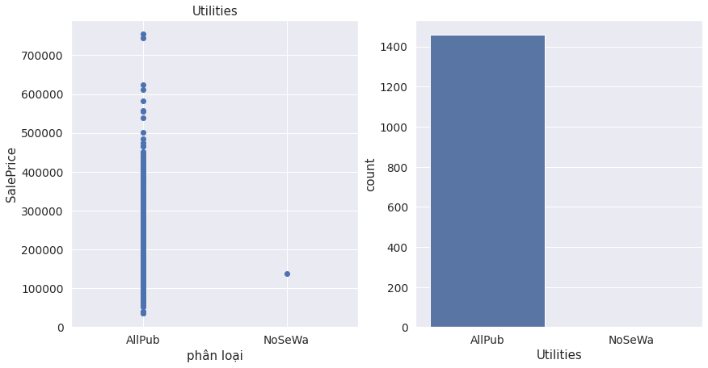

```python
feature = 'Utilities'
X = train[feature].dropna()
fig , (ax1, ax2) = plt.subplots(1,2, figsize=(14,7), sharex=True)
plt.subplot(ax1)
plot_feature(X)
plt.subplot(ax2)
if train[feature].dtype == np.dtype('object'):
    sns.countplot(X)
else:
    sns.distplot(X)
plt.show
```

#### Trường dữ liệu Utilities chênh lệch rất lớn giữa các lớp. Từ đó có thể xem xét drop (xóa) trường dữ liệu này khi làm "feature engineering"

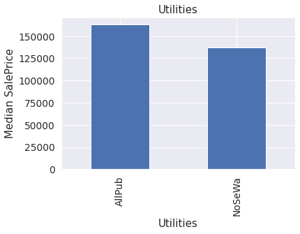

```python
train.groupby('Utilities')['SalePrice'].median().plot.bar()
plt.xlabel('Utilities')
plt.ylabel('Median SalePrice')
plt.title('Utilities')
plt.show()
```

#### Tương tự có thể làm thống kê cho các trường phân loại khác

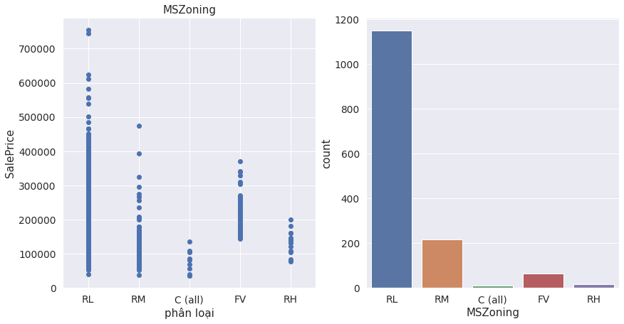

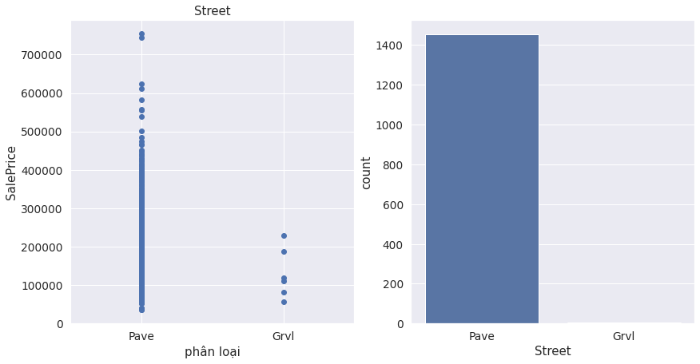

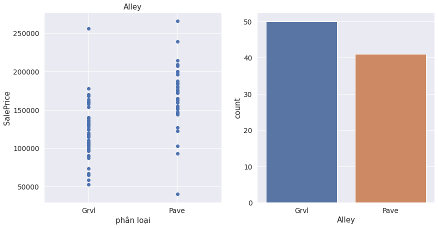

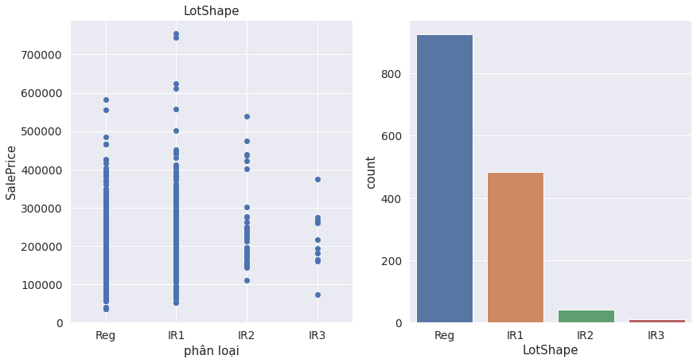

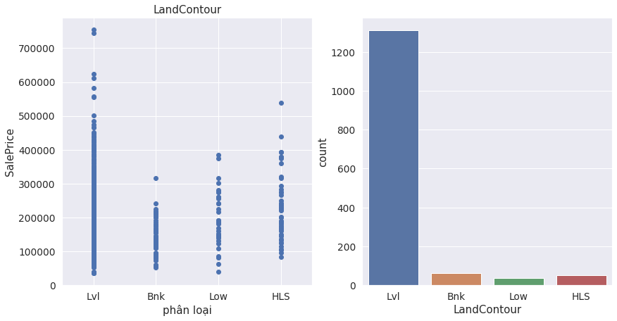

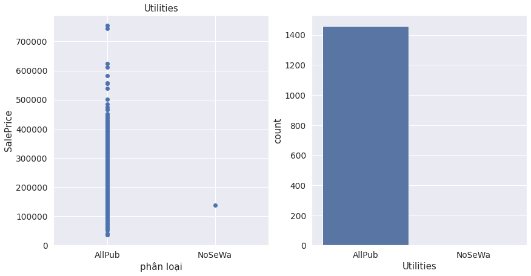

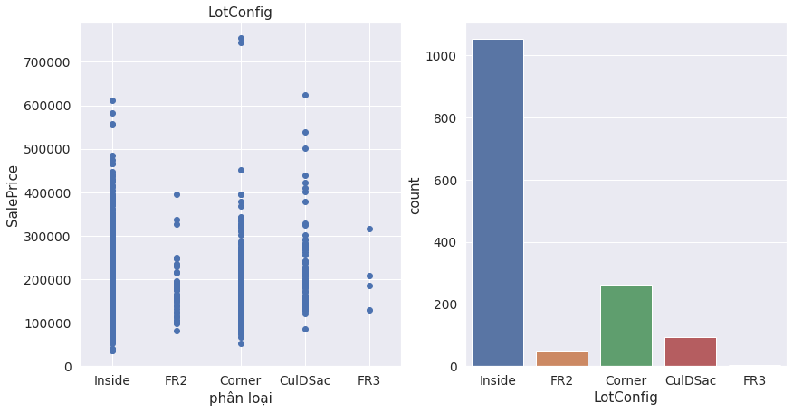

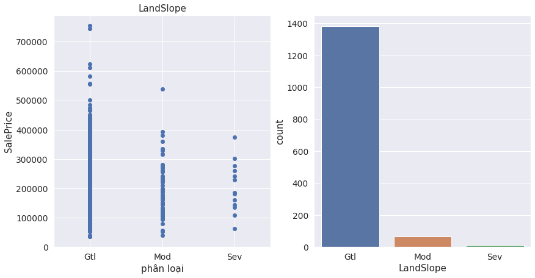

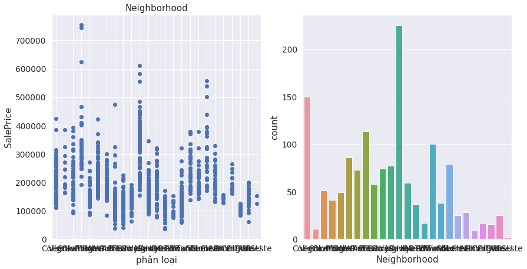

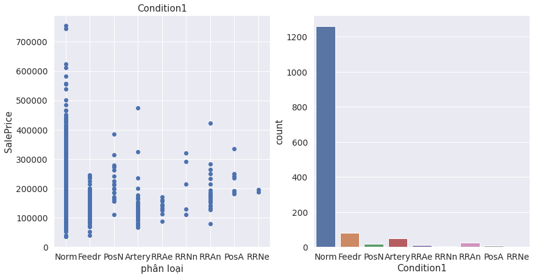

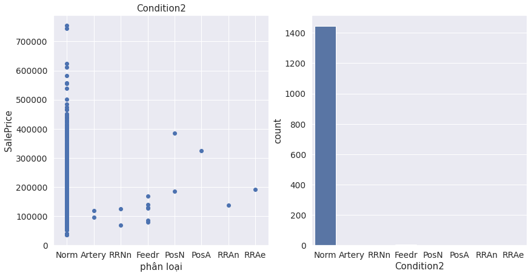

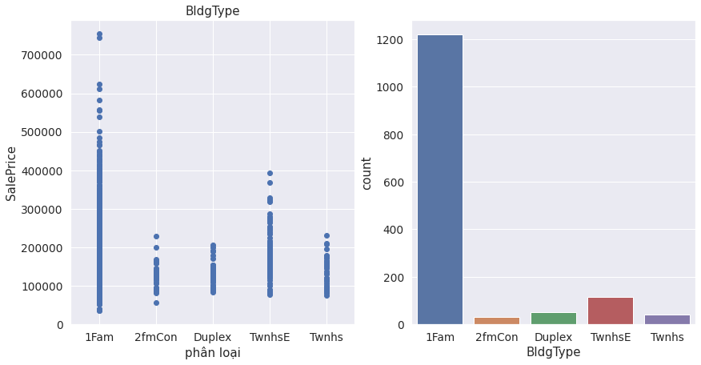

[31 more figures not shown]

```python
for feature in categorical_columns:

    X = train[feature].dropna()
    fig , (ax1, ax2) = plt.subplots(1,2, figsize=(14,7), sharex=True)
    plt.subplot(ax1)
    plot_feature(X)
    plt.subplot(ax2)
    if train[feature].dtype == np.dtype('object'):
        sns.countplot(X)
    else:
        sns.distplot(X)
plt.show()
```

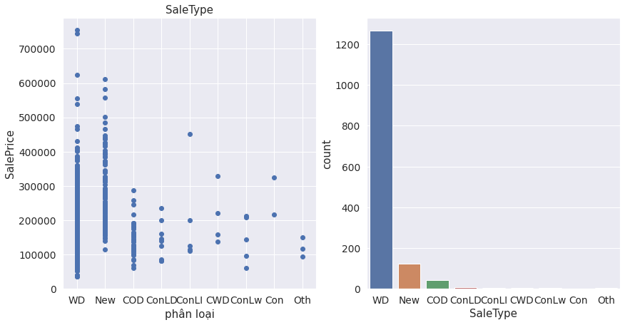

```python
feature = 'SaleType'

X = train[feature].dropna()
fig , (ax1, ax2) = plt.subplots(1,2, figsize=(14,7), sharex=True)
plt.subplot(ax1)
plot_feature(X)
plt.subplot(ax2)
if train[feature].dtype == np.dtype('object'):
    sns.countplot(X)
else:
    sns.distplot(X)
```

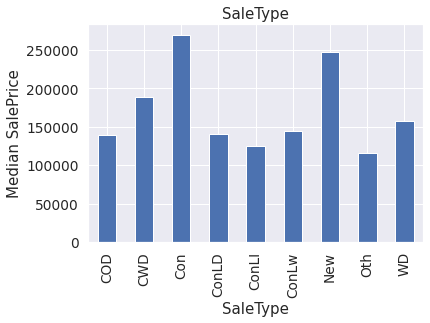

```python
train.groupby('SaleType')['SalePrice'].median().plot.bar()
plt.xlabel('SaleType')
plt.ylabel('Median SalePrice')
plt.title('SaleType')
plt.show()
```

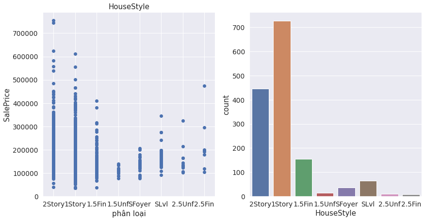

```python
feature = 'HouseStyle'
X = train[feature].dropna()
fig , (ax1, ax2) = plt.subplots(1,2, figsize=(14,7), sharex=True)
plt.subplot(ax1)
plot_feature(X)
plt.subplot(ax2)
if train[feature].dtype == np.dtype('object'):
    sns.countplot(X)
else:
    sns.distplot(X)
```

# 3. Feature engineering

- Chúng ta kết hợp cả tập train và test (gọi là data)
- Feature engineeing trên toàn bộ data. Sau đó chia lại 2 tập riêng dựa vào ID.
- Dùng dữ liệu train để xây dựng mô hình, predict trên tập test
- Sử dụng dữ liệu tập train, phân chia validation để đo đạc độ chính xác của mô hình.

### Tổng quan các bước xử lý data:

- Xóa các hàng có dữ liệu bất thường (là các hàng dữ liệu có diện tích lớn hơn 4000 và giá nhà nhỏ hơn 300.000)
- Xử lý dữ liệu thiếu:
  - Tạo cột dữ liệu mới tương ứng với NaN hoặc không Nan tương ứng với các cột dữ liệu thiếu
  - Điền NaN bằng các số liệu thích hợp hơn
- Xử lý dữ liệu dạng số :
  - Log transform với các cột dữ liệu có giá trị lớn
  - Xử lý các cột dữ liệu thời gian (cột năm xây dựng => cột thời gian sử dụng, tính tới năm 2018)
- Xử lý dữ liệu dạng phân loại:
  - One hot encoding

### Xóa các cột dữ liệu bất thường ở tập train

```python
train = train.drop(train[(train['GrLivArea']>4000) & (train['SalePrice']<300000)].index)
```

### Kết hợp cả tập train và test (gọi là data)

```python
ntrain = train.shape[0]
ntest = test.shape[0]
target = train.SalePrice.values
data = pd.concat((train, test)).reset_index(drop=True)
data.drop(['SalePrice'], axis=1, inplace=True)
print("data size is : {}".format(data.shape))
```

```
data size is : (2917, 79)
```

# 3.1. Xử lý missing data

[figure not shown]

#### Xem xét lại bảng missing data

```python
missing_values_table(data).head(10)
```

|  | Missing Values | % of Total Values |
| --- | --- | --- |
| PoolQC | 2908 | 99.7 |
| MiscFeature | 2812 | 96.4 |
| Alley | 2719 | 93.2 |
| Fence | 2346 | 80.4 |
| FireplaceQu | 1420 | 48.7 |
| LotFrontage | 486 | 16.7 |
| GarageFinish | 159 | 5.5 |
| GarageQual | 159 | 5.5 |
| GarageCond | 159 | 5.5 |
| GarageYrBlt | 159 | 5.5 |

```python
missing_values_table(data).index
```

```
Index(['PoolQC', 'MiscFeature', 'Alley', 'Fence', 'FireplaceQu', 'LotFrontage',
       'GarageFinish', 'GarageQual', 'GarageCond', 'GarageYrBlt', 'GarageType',
       'BsmtExposure', 'BsmtCond', 'BsmtQual', 'BsmtFinType2', 'BsmtFinType1',
       'MasVnrType', 'MasVnrArea', 'MSZoning', 'BsmtFullBath', 'BsmtHalfBath',
       'Functional', 'Utilities', 'GarageArea', 'GarageCars', 'Electrical',
       'KitchenQual', 'TotalBsmtSF', 'BsmtUnfSF', 'BsmtFinSF2', 'BsmtFinSF1',
       'Exterior2nd', 'Exterior1st', 'SaleType'],
      dtype='object')
```

Các hướng phổ biến để xử lý missing data:

- Tạo cột mới chứa thông tin Nan của trường dữ liệu (Nan or NonNan)
- Thay Nan bằng các giá trị phù hợp. Ví dụ: Với các dữ liệu số dương, thay Nan bằng các giá trị khác dấu (-1), giá trị lớn hơn hẳn (999), giá trị mean của trường dữ liệu,...
- Xây dựng mô hình dự đoán Nan sử dụng thông tin của các cột dữ liệu khác

#### Các trường có tỷ lệ missing cao : "PoolQC", "MiscFeature", "Alley", "FireplaceQu", "LotFrontage"

#### Tạo thêm cột mới xem cột có NaN hay không

```python
create_nan_columns = ["MiscFeature", "FireplaceQu", "Fence", "FireplaceQu", "LotFrontage"]
for feature in create_nan_columns:
    data[feature+"_NAN"] = data[feature].isnull()*1
```

#### Fill Nan

- Với các cột có tỉ lệ NaN thấp, có thể điền NaN bằng giá trị có tần suất xuất hiện lớn nhất. Ở đây chúng ta có các trường có tỉ lệ NaN thấp:

  MSZoning, BsmtFullBath, BsmtHalfBath, Functional, Utilities, GarageArea, GarageCars,

  Electrical, KitchenQual, TotalBsmtSF, BsmtUnfSF, BsmtFinSF2, BsmtFinSF1, Exterior2nd

  Exterior1st, SaleType
- Các cột còn lại chia thành 2 loại: Numeric và Categorical. Các dữ liệu số liên quan tới diện tích các kiểu phòng. Nguyên nhân missing data của các trường này thường do nhà thiết kế không có những loại phòng này (Garage). Nên với các trường số, fillna bởi 0, các trường phân loại sẽ fillnan bởi giá trị phân loại khác ("None").

#### Xử lý các trường dữ liệu có số lượng NaN ít

```python
rate_nan_columns = ['MSZoning', 'BsmtFullBath', 'BsmtHalfBath', 'Functional','Utilities',
                    'GarageArea','GarageCars','Electrical','KitchenQual','TotalBsmtSF',
                    'BsmtUnfSF', 'BsmtFinSF2',  'BsmtFinSF1','Exterior2nd', 'Exterior1st','SaleType']
for feature in rate_nan_columns:
    data[feature] = data[feature].fillna(data[feature].mode()[0])
```

#### Bảng missing thu được

```python
missing_values_table(data)
```

|  | Missing Values | % of Total Values |
| --- | --- | --- |
| PoolQC | 2908 | 99.7 |
| MiscFeature | 2812 | 96.4 |
| Alley | 2719 | 93.2 |
| Fence | 2346 | 80.4 |
| FireplaceQu | 1420 | 48.7 |
| LotFrontage | 486 | 16.7 |
| GarageYrBlt | 159 | 5.5 |
| GarageFinish | 159 | 5.5 |
| GarageQual | 159 | 5.5 |
| GarageCond | 159 | 5.5 |
| GarageType | 157 | 5.4 |
| BsmtCond | 82 | 2.8 |
| BsmtExposure | 82 | 2.8 |
| BsmtQual | 81 | 2.8 |
| BsmtFinType2 | 80 | 2.7 |
| BsmtFinType1 | 79 | 2.7 |
| MasVnrType | 24 | 0.8 |
| MasVnrArea | 23 | 0.8 |

Tên các trường bao gồm

```python
missing_values_table(data).index
```

```
Index(['PoolQC', 'MiscFeature', 'Alley', 'Fence', 'FireplaceQu', 'LotFrontage',
       'GarageYrBlt', 'GarageFinish', 'GarageQual', 'GarageCond', 'GarageType',
       'BsmtCond', 'BsmtExposure', 'BsmtQual', 'BsmtFinType2', 'BsmtFinType1',
       'MasVnrType', 'MasVnrArea'],
      dtype='object')
```

```python
numeric_nan = data[missing_values_table(data).index].select_dtypes(include=[np.number])
```

```python
categotical_nan = data[missing_values_table(data).index].select_dtypes(exclude=[np.number])
```

```python
numeric_nan
```

|  | LotFrontage | GarageYrBlt | MasVnrArea |
| --- | --- | --- | --- |
| 0 | 65.0 | 2003.0 | 196.0 |
| 1 | 80.0 | 1976.0 | 0.0 |
| 2 | 68.0 | 2001.0 | 162.0 |
| 3 | 60.0 | 1998.0 | 0.0 |
| 4 | 84.0 | 2000.0 | 350.0 |
| ... | ... | ... | ... |
| 2912 | 21.0 | NaN | 0.0 |
| 2913 | 21.0 | 1970.0 | 0.0 |
| 2914 | 160.0 | 1960.0 | 0.0 |
| 2915 | 62.0 | NaN | 0.0 |
| 2916 | 74.0 | 1993.0 | 94.0 |

2917 rows × 3 columns

```python
categotical_nan
```

|  | PoolQC | MiscFeature | Alley | Fence | FireplaceQu | GarageFinish | GarageQual | GarageCond | GarageType | BsmtCond | BsmtExposure | BsmtQual | BsmtFinType2 | BsmtFinType1 | MasVnrType |
| --- | --- | --- | --- | --- | --- | --- | --- | --- | --- | --- | --- | --- | --- | --- | --- |
| 0 | NaN | NaN | NaN | NaN | NaN | RFn | TA | TA | Attchd | TA | No | Gd | Unf | GLQ | BrkFace |
| 1 | NaN | NaN | NaN | NaN | TA | RFn | TA | TA | Attchd | TA | Gd | Gd | Unf | ALQ | None |
| 2 | NaN | NaN | NaN | NaN | TA | RFn | TA | TA | Attchd | TA | Mn | Gd | Unf | GLQ | BrkFace |
| 3 | NaN | NaN | NaN | NaN | Gd | Unf | TA | TA | Detchd | Gd | No | TA | Unf | ALQ | None |
| 4 | NaN | NaN | NaN | NaN | TA | RFn | TA | TA | Attchd | TA | Av | Gd | Unf | GLQ | BrkFace |
| ... | ... | ... | ... | ... | ... | ... | ... | ... | ... | ... | ... | ... | ... | ... | ... |
| 2912 | NaN | NaN | NaN | NaN | NaN | NaN | NaN | NaN | NaN | TA | No | TA | Unf | Unf | None |
| 2913 | NaN | NaN | NaN | NaN | NaN | Unf | TA | TA | CarPort | TA | No | TA | Unf | Rec | None |
| 2914 | NaN | NaN | NaN | NaN | TA | Unf | TA | TA | Detchd | TA | No | TA | Unf | ALQ | None |
| 2915 | NaN | Shed | NaN | MnPrv | NaN | NaN | NaN | NaN | NaN | TA | Av | Gd | Unf | GLQ | None |
| 2916 | NaN | NaN | NaN | NaN | TA | Fin | TA | TA | Attchd | TA | Av | Gd | Unf | LwQ | BrkFace |

2917 rows × 15 columns

#### Fillnan cho các trường số

```python
for feature in numeric_nan.columns:
    data[feature]= data[feature].fillna(0)
```

#### Fillnan cho các trường phân loại

```python
for feature in categotical_nan.columns:
    data[feature]= data[feature].fillna("None")
```

#### Kiểm tra kết quả NaN cuối cùng

```python
missing_values_table(data)
```

|  | Missing Values | % of Total Values |
| --- | --- | --- |

# 3.2. Xử lý dữ liệu dạng số

### Các hướng cơ bản xử lý dữ liệu dạng số

- Dữ liệu năm : Tạo cột mới chuyển feature năm sang feature thời gian
- Sử dụng transform log cho các cột dữ liệu có giá trị lớn

```python
numeric_features = data.select_dtypes(include=[np.number])
numeric_columns = numeric_features.columns
data[numeric_columns].head()
```

|  | MSSubClass | LotFrontage | LotArea | OverallQual | OverallCond | YearBuilt | YearRemodAdd | MasVnrArea | BsmtFinSF1 | BsmtFinSF2 | ... | 3SsnPorch | ScreenPorch | PoolArea | MiscVal | MoSold | YrSold | MiscFeature_NAN | FireplaceQu_NAN | Fence_NAN | LotFrontage_NAN |
| --- | --- | --- | --- | --- | --- | --- | --- | --- | --- | --- | --- | --- | --- | --- | --- | --- | --- | --- | --- | --- | --- |
| 0 | 60 | 65.0 | 8450 | 7 | 5 | 2003 | 2003 | 196.0 | 706.0 | 0.0 | ... | 0 | 0 | 0 | 0 | 2 | 2008 | 1 | 1 | 1 | 0 |
| 1 | 20 | 80.0 | 9600 | 6 | 8 | 1976 | 1976 | 0.0 | 978.0 | 0.0 | ... | 0 | 0 | 0 | 0 | 5 | 2007 | 1 | 0 | 1 | 0 |
| 2 | 60 | 68.0 | 11250 | 7 | 5 | 2001 | 2002 | 162.0 | 486.0 | 0.0 | ... | 0 | 0 | 0 | 0 | 9 | 2008 | 1 | 0 | 1 | 0 |
| 3 | 70 | 60.0 | 9550 | 7 | 5 | 1915 | 1970 | 0.0 | 216.0 | 0.0 | ... | 0 | 0 | 0 | 0 | 2 | 2006 | 1 | 0 | 1 | 0 |
| 4 | 60 | 84.0 | 14260 | 8 | 5 | 2000 | 2000 | 350.0 | 655.0 | 0.0 | ... | 0 | 0 | 0 | 0 | 12 | 2008 | 1 | 0 | 1 | 0 |

5 rows × 40 columns

```python
numeric_columns
```

```
Index(['MSSubClass', 'LotFrontage', 'LotArea', 'OverallQual', 'OverallCond',
       'YearBuilt', 'YearRemodAdd', 'MasVnrArea', 'BsmtFinSF1', 'BsmtFinSF2',
       'BsmtUnfSF', 'TotalBsmtSF', '1stFlrSF', '2ndFlrSF', 'LowQualFinSF',
       'GrLivArea', 'BsmtFullBath', 'BsmtHalfBath', 'FullBath', 'HalfBath',
       'BedroomAbvGr', 'KitchenAbvGr', 'TotRmsAbvGrd', 'Fireplaces',
       'GarageYrBlt', 'GarageCars', 'GarageArea', 'WoodDeckSF', 'OpenPorchSF',
       'EnclosedPorch', '3SsnPorch', 'ScreenPorch', 'PoolArea', 'MiscVal',
       'MoSold', 'YrSold', 'MiscFeature_NAN', 'FireplaceQu_NAN', 'Fence_NAN',
       'LotFrontage_NAN'],
      dtype='object')
```

#### Có 3 cột dữ liệu năm: "YearBuilt", "YearRemodAdd", "GarageYrBlt"

#### Tạo 3 cột dữ liệu mới

```python
data['YearBuiltDur'] = 2018 - data['YearBuilt']
data['YearRemodAddDur'] = 2018 - data['YearRemodAdd']
data['GarageYrBltDur'] = 2018 - data['GarageYrBlt']
```

#### Sử dụng phép biến đổi log cho những cột chênh lệch lớn

[figure not shown]

```python
transform_columns = ["LotArea", "MasVnrArea", "BsmtFinSF1","BsmtUnfSF", "TotalBsmtSF",
                     "1stFlrSF","2ndFlrSF", "GrLivArea","GarageArea", "WoodDeckSF",
                     "OpenPorchSF","3SsnPorch","ScreenPorch", "PoolArea"]
```

```python
#data[transform_columns] = data[transform_columns].replace(0, np.nan)
data.loc[:,transform_columns] = np.log1p(data[transform_columns])
#data[transform_columns] = data[transform_columns].replace(np.nan, 0)
data[transform_columns].head(10)
```

|  | LotArea | MasVnrArea | BsmtFinSF1 | BsmtUnfSF | TotalBsmtSF | 1stFlrSF | 2ndFlrSF | GrLivArea | GarageArea | WoodDeckSF | OpenPorchSF | 3SsnPorch | ScreenPorch | PoolArea |
| --- | --- | --- | --- | --- | --- | --- | --- | --- | --- | --- | --- | --- | --- | --- |
| 0 | 9.042040 | 5.283204 | 6.561031 | 5.017280 | 6.753438 | 6.753438 | 6.751101 | 7.444833 | 6.308098 | 0.000000 | 4.127134 | 0.000000 | 0.0 | 0.0 |
| 1 | 9.169623 | 0.000000 | 6.886532 | 5.652489 | 7.141245 | 7.141245 | 0.000000 | 7.141245 | 6.133398 | 5.700444 | 0.000000 | 0.000000 | 0.0 | 0.0 |
| 2 | 9.328212 | 5.093750 | 6.188264 | 6.075346 | 6.825460 | 6.825460 | 6.765039 | 7.488294 | 6.411818 | 0.000000 | 3.761200 | 0.000000 | 0.0 | 0.0 |
| 3 | 9.164401 | 0.000000 | 5.379897 | 6.293419 | 6.629363 | 6.869014 | 6.629363 | 7.448916 | 6.466145 | 0.000000 | 3.583519 | 0.000000 | 0.0 | 0.0 |
| 4 | 9.565284 | 5.860786 | 6.486161 | 6.196444 | 7.044033 | 7.044033 | 6.960348 | 7.695758 | 6.729824 | 5.262690 | 4.442651 | 0.000000 | 0.0 | 0.0 |
| 5 | 9.555064 | 0.000000 | 6.597146 | 4.174387 | 6.680855 | 6.680855 | 6.340359 | 7.217443 | 6.175867 | 3.713572 | 3.433987 | 5.771441 | 0.0 | 0.0 |
| 6 | 9.218804 | 5.231109 | 7.222566 | 5.762051 | 7.430707 | 7.435438 | 0.000000 | 7.435438 | 6.456770 | 5.545177 | 4.060443 | 0.000000 | 0.0 | 0.0 |
| 7 | 9.247925 | 5.484797 | 6.756932 | 5.379897 | 7.010312 | 7.010312 | 6.891626 | 7.645398 | 6.184149 | 5.463832 | 5.323010 | 0.000000 | 0.0 | 0.0 |
| 8 | 8.719481 | 0.000000 | 0.000000 | 6.859615 | 6.859615 | 6.930495 | 6.624065 | 7.481556 | 6.150603 | 4.510860 | 0.000000 | 0.000000 | 0.0 | 0.0 |
| 9 | 8.912069 | 0.000000 | 6.747587 | 4.948760 | 6.899723 | 6.982863 | 0.000000 | 6.982863 | 5.327876 | 0.000000 | 1.609438 | 0.000000 | 0.0 | 0.0 |

# 3.3. Xử lý dữ liệu dạng phân loại

### Với dữ liệu phân loại, có nhiều phương pháp giúp [encoding](https://towardsdatascience.com/all-about-categorical-variable-encoding-305f3361fd02):

- One Hot Encoding
- Label Encoding
- Frequency Encoding
- Mean Encoding
- Target encoding
- Weight of Evidence Encoding
- Entity Encoding

Khi xây dựng baseline cho mô hình, chúng ta sẽ sử dụng One Hot Encoding.

Lưu ý khi sử dụng encoding: để đảm bảo số chiều tương thích của tập train và test, encoding cần được áp dụng cho cả tập train và test (toàn tập data); như vậy, trong trường hợp tập test không có một lớp phân loại bất kỳ thì số lượng dữ liệu ở tập train sẽ đủ nhiều để có thể vét hết tất cả lớp phân loại của trên tập test.

#### One Hot Encoding

One Hot Encoding tạo các cột mới cho biết sự hiện diện (hoặc vắng mặt) của mỗi giá trị có thể có trong dữ liệu. Để hiểu rõ, cùng xem xét hình dưới

[figure not shown]

```python
categorical_features = data.select_dtypes(exclude=[np.number])
categorical_columns = categorical_features.columns
data[categorical_columns].head()
```

|  | MSZoning | Street | Alley | LotShape | LandContour | Utilities | LotConfig | LandSlope | Neighborhood | Condition1 | ... | GarageType | GarageFinish | GarageQual | GarageCond | PavedDrive | PoolQC | Fence | MiscFeature | SaleType | SaleCondition |
| --- | --- | --- | --- | --- | --- | --- | --- | --- | --- | --- | --- | --- | --- | --- | --- | --- | --- | --- | --- | --- | --- |
| 0 | RL | Pave | None | Reg | Lvl | AllPub | Inside | Gtl | CollgCr | Norm | ... | Attchd | RFn | TA | TA | Y | None | None | None | WD | Normal |
| 1 | RL | Pave | None | Reg | Lvl | AllPub | FR2 | Gtl | Veenker | Feedr | ... | Attchd | RFn | TA | TA | Y | None | None | None | WD | Normal |
| 2 | RL | Pave | None | IR1 | Lvl | AllPub | Inside | Gtl | CollgCr | Norm | ... | Attchd | RFn | TA | TA | Y | None | None | None | WD | Normal |
| 3 | RL | Pave | None | IR1 | Lvl | AllPub | Corner | Gtl | Crawfor | Norm | ... | Detchd | Unf | TA | TA | Y | None | None | None | WD | Abnorml |
| 4 | RL | Pave | None | IR1 | Lvl | AllPub | FR2 | Gtl | NoRidge | Norm | ... | Attchd | RFn | TA | TA | Y | None | None | None | WD | Normal |

5 rows × 43 columns

### One hot encoding

Sử dụng lệnh get_dummies của pandas để thực hiện one hot encooding

```python
data = pd.get_dummies(data)
print(data.shape)
```

```
(2917, 308)
```

```python
data.head()
```

|  | MSSubClass | LotFrontage | LotArea | OverallQual | OverallCond | YearBuilt | YearRemodAdd | MasVnrArea | BsmtFinSF1 | BsmtFinSF2 | ... | SaleType_ConLw | SaleType_New | SaleType_Oth | SaleType_WD | SaleCondition_Abnorml | SaleCondition_AdjLand | SaleCondition_Alloca | SaleCondition_Family | SaleCondition_Normal | SaleCondition_Partial |
| --- | --- | --- | --- | --- | --- | --- | --- | --- | --- | --- | --- | --- | --- | --- | --- | --- | --- | --- | --- | --- | --- |
| 0 | 60 | 65.0 | 9.042040 | 7 | 5 | 2003 | 2003 | 5.283204 | 6.561031 | 0.0 | ... | 0 | 0 | 0 | 1 | 0 | 0 | 0 | 0 | 1 | 0 |
| 1 | 20 | 80.0 | 9.169623 | 6 | 8 | 1976 | 1976 | 0.000000 | 6.886532 | 0.0 | ... | 0 | 0 | 0 | 1 | 0 | 0 | 0 | 0 | 1 | 0 |
| 2 | 60 | 68.0 | 9.328212 | 7 | 5 | 2001 | 2002 | 5.093750 | 6.188264 | 0.0 | ... | 0 | 0 | 0 | 1 | 0 | 0 | 0 | 0 | 1 | 0 |
| 3 | 70 | 60.0 | 9.164401 | 7 | 5 | 1915 | 1970 | 0.000000 | 5.379897 | 0.0 | ... | 0 | 0 | 0 | 1 | 1 | 0 | 0 | 0 | 0 | 0 |
| 4 | 60 | 84.0 | 9.565284 | 8 | 5 | 2000 | 2000 | 5.860786 | 6.486161 | 0.0 | ... | 0 | 0 | 0 | 1 | 0 | 0 | 0 | 0 | 1 | 0 |

5 rows × 308 columns

```python
target = train['SalePrice'].values
```

```python
train_set = data[:ntrain]
test_set = data[ntrain:]
```

```python
test_set.head(10)
```

|  | MSSubClass | LotFrontage | LotArea | OverallQual | OverallCond | YearBuilt | YearRemodAdd | MasVnrArea | BsmtFinSF1 | BsmtFinSF2 | ... | SaleType_ConLw | SaleType_New | SaleType_Oth | SaleType_WD | SaleCondition_Abnorml | SaleCondition_AdjLand | SaleCondition_Alloca | SaleCondition_Family | SaleCondition_Normal | SaleCondition_Partial |
| --- | --- | --- | --- | --- | --- | --- | --- | --- | --- | --- | --- | --- | --- | --- | --- | --- | --- | --- | --- | --- | --- |
| 1458 | 20 | 80.0 | 9.360741 | 5 | 6 | 1961 | 1961 | 0.000000 | 6.150603 | 144.0 | ... | 0 | 0 | 0 | 1 | 0 | 0 | 0 | 0 | 1 | 0 |
| 1459 | 20 | 81.0 | 9.565775 | 6 | 6 | 1958 | 1958 | 4.691348 | 6.828712 | 0.0 | ... | 0 | 0 | 0 | 1 | 0 | 0 | 0 | 0 | 1 | 0 |
| 1460 | 60 | 74.0 | 9.534668 | 5 | 5 | 1997 | 1998 | 0.000000 | 6.674561 | 0.0 | ... | 0 | 0 | 0 | 1 | 0 | 0 | 0 | 0 | 1 | 0 |
| 1461 | 60 | 78.0 | 9.208238 | 6 | 6 | 1998 | 1998 | 3.044522 | 6.401917 | 0.0 | ... | 0 | 0 | 0 | 1 | 0 | 0 | 0 | 0 | 1 | 0 |
| 1462 | 120 | 43.0 | 8.518392 | 8 | 5 | 1992 | 1992 | 0.000000 | 5.575949 | 0.0 | ... | 0 | 0 | 0 | 1 | 0 | 0 | 0 | 0 | 1 | 0 |
| 1463 | 60 | 75.0 | 9.210440 | 6 | 5 | 1993 | 1994 | 0.000000 | 0.000000 | 0.0 | ... | 0 | 0 | 0 | 1 | 0 | 0 | 0 | 0 | 1 | 0 |
| 1464 | 20 | 0.0 | 8.984819 | 6 | 7 | 1992 | 2007 | 0.000000 | 6.841615 | 0.0 | ... | 0 | 0 | 0 | 1 | 0 | 0 | 0 | 0 | 1 | 0 |
| 1465 | 60 | 63.0 | 9.036344 | 6 | 5 | 1998 | 1998 | 0.000000 | 0.000000 | 0.0 | ... | 0 | 0 | 0 | 1 | 0 | 0 | 0 | 0 | 1 | 0 |
| 1466 | 20 | 85.0 | 9.227886 | 7 | 5 | 1990 | 1990 | 0.000000 | 6.458338 | 0.0 | ... | 0 | 0 | 0 | 1 | 0 | 0 | 0 | 0 | 1 | 0 |
| 1467 | 20 | 70.0 | 9.036106 | 4 | 5 | 1970 | 1970 | 0.000000 | 6.690842 | 78.0 | ... | 0 | 0 | 0 | 1 | 0 | 0 | 0 | 0 | 1 | 0 |

10 rows × 308 columns

```python
train_set.head(10)
```

|  | MSSubClass | LotFrontage | LotArea | OverallQual | OverallCond | YearBuilt | YearRemodAdd | MasVnrArea | BsmtFinSF1 | BsmtFinSF2 | ... | SaleType_ConLw | SaleType_New | SaleType_Oth | SaleType_WD | SaleCondition_Abnorml | SaleCondition_AdjLand | SaleCondition_Alloca | SaleCondition_Family | SaleCondition_Normal | SaleCondition_Partial |
| --- | --- | --- | --- | --- | --- | --- | --- | --- | --- | --- | --- | --- | --- | --- | --- | --- | --- | --- | --- | --- | --- |
| 0 | 60 | 65.0 | 9.042040 | 7 | 5 | 2003 | 2003 | 5.283204 | 6.561031 | 0.0 | ... | 0 | 0 | 0 | 1 | 0 | 0 | 0 | 0 | 1 | 0 |
| 1 | 20 | 80.0 | 9.169623 | 6 | 8 | 1976 | 1976 | 0.000000 | 6.886532 | 0.0 | ... | 0 | 0 | 0 | 1 | 0 | 0 | 0 | 0 | 1 | 0 |
| 2 | 60 | 68.0 | 9.328212 | 7 | 5 | 2001 | 2002 | 5.093750 | 6.188264 | 0.0 | ... | 0 | 0 | 0 | 1 | 0 | 0 | 0 | 0 | 1 | 0 |
| 3 | 70 | 60.0 | 9.164401 | 7 | 5 | 1915 | 1970 | 0.000000 | 5.379897 | 0.0 | ... | 0 | 0 | 0 | 1 | 1 | 0 | 0 | 0 | 0 | 0 |
| 4 | 60 | 84.0 | 9.565284 | 8 | 5 | 2000 | 2000 | 5.860786 | 6.486161 | 0.0 | ... | 0 | 0 | 0 | 1 | 0 | 0 | 0 | 0 | 1 | 0 |
| 5 | 50 | 85.0 | 9.555064 | 5 | 5 | 1993 | 1995 | 0.000000 | 6.597146 | 0.0 | ... | 0 | 0 | 0 | 1 | 0 | 0 | 0 | 0 | 1 | 0 |
| 6 | 20 | 75.0 | 9.218804 | 8 | 5 | 2004 | 2005 | 5.231109 | 7.222566 | 0.0 | ... | 0 | 0 | 0 | 1 | 0 | 0 | 0 | 0 | 1 | 0 |
| 7 | 60 | 0.0 | 9.247925 | 7 | 6 | 1973 | 1973 | 5.484797 | 6.756932 | 32.0 | ... | 0 | 0 | 0 | 1 | 0 | 0 | 0 | 0 | 1 | 0 |
| 8 | 50 | 51.0 | 8.719481 | 7 | 5 | 1931 | 1950 | 0.000000 | 0.000000 | 0.0 | ... | 0 | 0 | 0 | 1 | 1 | 0 | 0 | 0 | 0 | 0 |
| 9 | 190 | 50.0 | 8.912069 | 5 | 6 | 1939 | 1950 | 0.000000 | 6.747587 | 0.0 | ... | 0 | 0 | 0 | 1 | 0 | 0 | 0 | 0 | 1 | 0 |

10 rows × 308 columns

# 4. Xây dựng mô hình

# 4.1. Xây dựng cross validation

Cross-validation là quy trình phân chia dữ liệu để đánh giá độ chính xác của mô hình trong trường hợp dữ liệu ít

Ví dụ: Chúng ta chia tập dữ liệu ra 5 phần, mỗi phần chiếm 20% dữ liệu

[figure not shown]

Tiến hành huấn luyện sử dụng cùng một loại mô hình.

**Mô hình 1**: Sử dụng phần đầu tiên của dữ liệu làm tập validation thứ 1, 4 phần còn lại làm dữ liệu huấn luyện

**Mô hình 2**: Sử dụng phần thứ hai của dữ liệu làm tập validation thứ 2, 4 phần còn lại làm dữ liệu huấn luyện, mô hình được sử dụng với cùng một loại tham số với mô hình 1.

Tiếp tục xây dựng các mô hình. Kết hợp các validation thứ $i$ của mô hình $i$, chúng ta được tập validation trên toàn bộ $100\%$ dữ liệu.

**Ưu điểm của việc sử dụng Cross-validation**:

- Validation trên tập dữ liệu lớn hơn (100% dữ liệu thay vì chỉ 20% dữ liệu) giúp cho thước đo mức độ chính xác của mô hình đảm bảo tin tưởng hơn
- Tránh được trường hợp overfitting
- Khi thực hiện dự đoán với tổng hợp của cả 5 mô hình thì độ chính xác cao hơn, vì mô hình được học trên toàn bộ dữ liệu

**Nhược điểm của việc sử dụng Cross-validation**:

- Để đánh giá một loại mô hình cần sử dụng 5 lần huấn luyện (tốn thời gian huấn luyện)

**Vậy khi nào nên sử dụng Cross-validation**:

- Trong trường hợp dữ liệu ít, mô hình không quá cồng kềnh. Trong trường hợp có nhiều dữ liệu, dữ liệu có tính tổng quát cao, không nhất thiết phải dùng cross-validation.

Sử dụng gói thư viện scikit-learn để phân chia dữ liệu theo K-fold

# 4.2. Xây dựng các mô hình cơ bản

# 4.2..1. Mô hình Lightgbm

```python
target = np.log1p(train['SalePrice'].values)
```

#### Định nghĩa tham số của thuật toán lightgbm và hàm huấn luyện trên một fold

```python
params = {
        "objective" : "regression",
        "metric" : "rmse",
        "num_leaves" : 8,
        "learning_rate" : 0.05,
        "bagging_fraction" : 0.5,
        "feature_fraction" : 0.5,
        "bagging_frequency" : 5,
        "bagging_seed" : 2020,
        "verbosity" : -1 }
def run_lgb(train_X, train_y, valid_X, valid_y, test_X,params):
    """
    args:
    + train_X : training dataset
    + valid_X : validataion dataset
    + train_y : target of training set
    + valid_y : target of validation set
    +params : parameters of lightgbm

    output:
    + pred_test_y : prediction of testing set
    + model   : The lightgbm model which is trained by the train_X, train_y
    """
    lgtrain = lgb.Dataset(train_X, label=train_y)
    lgval = lgb.Dataset(valid_X, label=valid_y)
    evals_result = {}
    model = lgb.train(params, lgtrain, 2000, valid_sets=[lgval], early_stopping_rounds=100, verbose_eval=200, evals_result=evals_result)
    pred_test_y = model.predict(test_X, num_iteration=model.best_iteration)
    return pred_test_y, model
```

#### Định nghĩa mô hình huấn luyện trên toàn bộ k-fold, dựa trên hàm run_lgb

```python
def model_kf(train_set, target,test_set, params):
    kf = KFold(n_splits=5, shuffle = True, random_state = 2020) ## định nghĩa k-fold
    pred_test_full = 0
# Sử dụng loop để huấn luyện mỗi fold
    oof_preds = np.zeros(train_set.shape[0]) ## out of fold prediction
    for train_index, valid_index in kf.split(train_set):
        X_train , X_valid  = train_set.loc[train_index,:], train_set.loc[valid_index,:]
        y_train, y_valid = target[train_index], target[valid_index]
        pred_test, model = run_lgb(X_train, y_train, X_valid, y_valid, test_set, params) ## get testing prediction and model
        pred_test_full += pred_test ## prediction of testing data
        oof_preds[valid_index] = model.predict(train_set.loc[valid_index,:])  # prediction of out of fold
    print('Full Out-Of-Fold score : %9.6f'
          % (mean_squared_error(target, oof_preds) ** .5))
    pred_test_full /= 5
    pred_test_full = np.expm1(pred_test_full)
    return pred_test_full, oof_preds, model
pred_test_full, oof_preds, model = model_kf(train_set, target,test_set,params)
```

```
[LightGBM] [Warning] Unknown parameter: bagging_frequency
Training until validation scores don't improve for 100 rounds
[200]	valid_0's rmse: 0.11989
[400]	valid_0's rmse: 0.118948
Early stopping, best iteration is:
[388]	valid_0's rmse: 0.118866
[LightGBM] [Warning] Unknown parameter: bagging_frequency
Training until validation scores don't improve for 100 rounds
[200]	valid_0's rmse: 0.121726
[400]	valid_0's rmse: 0.11807
Early stopping, best iteration is:
[491]	valid_0's rmse: 0.117824
[LightGBM] [Warning] Unknown parameter: bagging_frequency
Training until validation scores don't improve for 100 rounds
[200]	valid_0's rmse: 0.124552
Early stopping, best iteration is:
[273]	valid_0's rmse: 0.123981
[LightGBM] [Warning] Unknown parameter: bagging_frequency
Training until validation scores don't improve for 100 rounds
[200]	valid_0's rmse: 0.126517
Early stopping, best iteration is:
[150]	valid_0's rmse: 0.125821
[LightGBM] [Warning] Unknown parameter: bagging_frequency
Training until validation scores don't improve for 100 rounds
[200]	valid_0's rmse: 0.122736
[400]	valid_0's rmse: 0.120407
[600]	valid_0's rmse: 0.119415
[800]	valid_0's rmse: 0.118415
Early stopping, best iteration is:
[780]	valid_0's rmse: 0.118276
Full Out-Of-Fold score :  0.120997
```

#### Điểm RMSLE trên cả tập dữ liệu đạt: 0.121

#### In ra các trường quan trọng đóng góp trong mô hình lightgbm

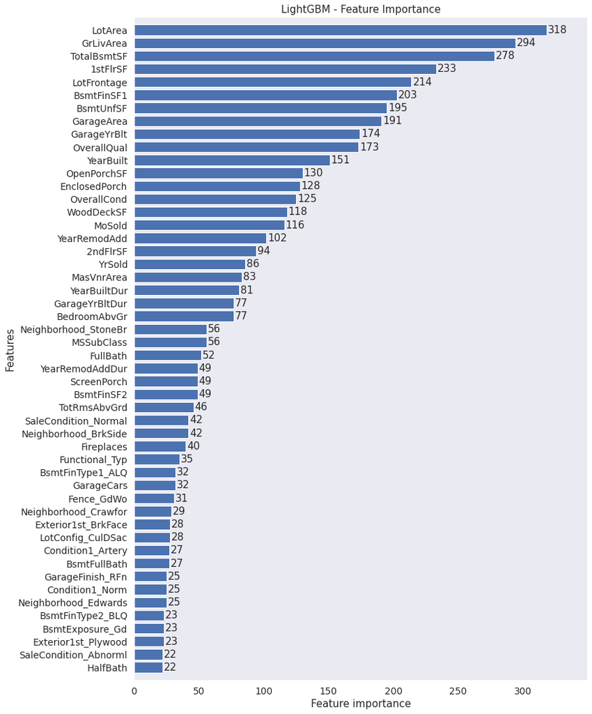

```python
fig, ax = plt.subplots(figsize=(12,18))
lgb.plot_importance(model, max_num_features=50, height=0.8, ax=ax)
ax.grid(False)
plt.title("LightGBM - Feature Importance", fontsize=15)
plt.show()
```